# Reproducible Research Course: Peer Assessment Project 1

Anthony Efonemchi

23 10 2020

# Background Information of the Assignment

It is now possible to collect a large amount of data about personal movement using activity monitoring devices such as a Fitbit, Nike Fuelband, or Jawbone Up. These type of devices are part of the “quantified self” movement – a group of enthusiasts who take measurements about themselves regularly to improve their health, to find patterns in their behavior, or because they are tech geeks. But these data remain under-utilized both because the raw data are hard to obtain and there is a lack of statistical methods and software for processing and interpreting the data.

This assignment makes use of data from a personal activity monitoring device. This device collects data at 5 minute intervals through out the day. The data consists of two months of data from an anonymous individual collected during the months of October and November, 2012 and include the number of steps taken in 5 minute intervals each day.

## Data

The dataset for this assignment can be downloaded from the course web site: [Activity monitoring data](https://github.com/rdpeng/RepData_PeerAssessment1)

The variables included in this dataset are:

**steps:** Number of steps taking in a 5-minute interval (missing values are coded as NA)

**date:** The date on which the measurement was taken in YYYY-MM-DD format

**interval:** Identifier for the 5-minute interval in which measurement was taken

The dataset is stored in a comma-separated-value (CSV) file and there are a total of 17,568 observations in this dataset.

## Load libraries

```r
library(dplyr)
```

```r
library(ggplot2)
# Change time locale for R if need be.
Sys.setlocale("LC_TIME", "English")
```

```
## [1] "English_United States.1252"
```

### Load and preprocess the data for the project.

```r
# Load core data.
activity <- read.csv("activity.csv")
```

```r
# Inspect the dataset for a quick overview.
summary(activity)
```

```
##      steps                date          interval
##  Min.   :  0.00   2012-10-01:  288   Min.   :   0.0
##  1st Qu.:  0.00   2012-10-02:  288   1st Qu.: 588.8
##  Median :  0.00   2012-10-03:  288   Median :1177.5
##  Mean   : 37.38   2012-10-04:  288   Mean   :1177.5
##  3rd Qu.: 12.00   2012-10-05:  288   3rd Qu.:1766.2
##  Max.   :806.00   2012-10-06:  288   Max.   :2355.0
##  NA's   :2304     (Other)   :15840
```

```r
str(activity)
```

```
## 'data.frame':    17568 obs. of  3 variables:
##  $ steps   : int  NA NA NA NA NA NA NA NA NA NA ...
##  $ date    : Factor w/ 61 levels "2012-10-01","2012-10-02",..: 1 1 1 1 1 1 1 1 1 1 ...
##  $ interval: int  0 5 10 15 20 25 30 35 40 45 ...
```

# **Questions**

## 1. What is the mean total number of steps taken per day?

### i. Total number of steps taken per day.

```r
# Deploy the aggregate function, remove NAs.
daily_Steps <- aggregate(steps ~ date, data = activity, FUN = sum, na.rm = TRUE)
```

### ii. Construct the histogram of the total number of steps taken each day.

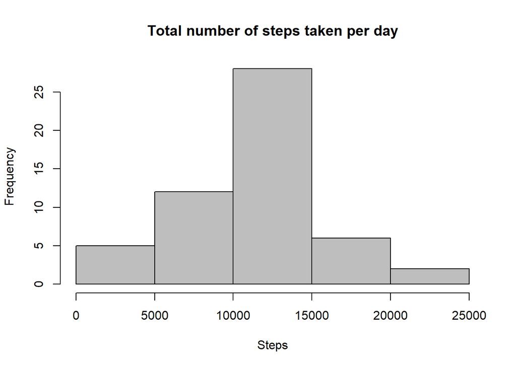

```r
# Plot the histogram with base plotting
hist(daily_Steps$steps, xlab = "Steps", main = "Total number of steps taken per day", col = "grey")
```

### iii. Mean and median of the total number of steps taken per day.

```r
# Mean
mean(daily_Steps$steps, na.rm=TRUE)
```

```
## [1] 10766.19
```

```r
# Median
median(daily_Steps$steps, na.rm=TRUE)
```

```
## [1] 10765
```